# MidTerm

## III. Predictive Models

Continue with the data from part I. Make sure you do not have any missing values in the data. Use the follows as the target and input variables:

```r
# Checking for missing values by column in NA form.

df %>% is.na %>% colSums
```

```
##      yod pay_ub92      age      sex raceethn provider      moa      yoa
##        0        0        0        0        0        0        0        0
##      mod  admtype  asource      los  service      icu      ccu dispub92
##        0        0        0        0        0        0        0        0
##    payer      drg   trandb   randbg   randbs      orr     anes      seq
##        0        0        0        0        0        0        0        0
##      lab    dtest     ther    blood     phar    other   patcon    bwght
##        0        0        0        0        0        0        0        0
##    total      tot ecodub92     b_wt pt_state diag_adm  ancilar   campus
##        0        0        0        0        0        0        0        0
##   er_fee  er_chrg  er_mode obs_chrg psycchrg   season
##        0        0        0        0        0        0
```

*Target Variable*: Create the target variable taking value of

- `low` if the total charge of a patient (`tot`) is smaller than the median of the total charge, and
- `high` otherwise.

```r
# Using the ifelse function to test if the total charge for a patient is less than the average. If so, the variable takes the value 'low', else it will take on the value 'high'.

df$target <- ifelse(df$tot < mean(df$tot), 'low','high')
head(df)
```

```
## # A tibble: 6 × 47
##     yod pay_ub92   age sex   raceethn provider   moa   yoa   mod admtype asource
##   <dbl>    <dbl> <dbl> <chr> <chr>    <chr>    <dbl> <dbl> <dbl> <chr>   <chr>
## 1    18        9     0 1     1        7214         1    18     1 4       S
## 2    18        2    76 2     1        7214         1    18     1 3       1
## 3    18        6    50 2     1        7214        12    17     1 2       1
## 4    18        4     0 1     7        7214         1    18     1 4       S
## 5    18       13     0 1     1        7214        12    17     1 4       S
## 6    18        4     0 2     9        7214        12    17     1 4       T
## # ℹ 36 more variables: los <dbl>, service <chr>, icu <chr>, ccu <chr>,
## #   dispub92 <chr>, payer <chr>, drg <dbl>, trandb <chr>, randbg <chr>,
## #   randbs <chr>, orr <chr>, anes <chr>, seq <chr>, lab <chr>, dtest <chr>,
## #   ther <chr>, blood <chr>, phar <chr>, other <chr>, patcon <chr>,
## #   bwght <chr>, total <chr>, tot <dbl>, ecodub92 <chr>, b_wt <chr>,
## #   pt_state <chr>, diag_adm <chr>, ancilar <chr>, campus <chr>, er_fee <chr>,
## #   er_chrg <chr>, er_mode <chr>, obs_chrg <chr>, psycchrg <chr>, …
```

*Input Variables*:

- “age”,“sex”,“raceethn”,“provider”,“moa”,“mod”,“admtype”,“campus”, ‘los’
1. Use `filter` function to filter out rows where `raceethn==''` or `admtype==''`. Make sure all the categorical variables are factor, numeric variables are numeric. Set Training : Testing Split = 10 : 90

```r
# Using the 'filter' function to remove the rows were the variables `raceethn` or `admtype` had empty values. The changes are saved to the dataframe.

df <- df %>% filter(raceethn != '' & admtype != '') %>%
  select("age","sex","raceethn","provider","moa","mod","admtype","campus", "los", "target")

head(df)
```

```
## # A tibble: 6 × 10
##     age sex   raceethn provider   moa   mod admtype campus   los target
##   <dbl> <chr> <chr>    <chr>    <dbl> <dbl> <chr>   <chr>  <dbl> <chr>
## 1     0 1     1        7214         1     1 4       0          2 low
## 2    76 2     1        7214         1     1 3       0          1 high
## 3    50 2     1        7214        12     1 2       0          3 high
## 4     0 1     7        7214         1     1 4       0          4 low
## 5     0 1     1        7214        12     1 4       0         35 high
## 6     0 2     9        7214        12     1 4       0         17 high
```

```r
# Updating the class of the variables in the dataframe to numeric and factor with mutate. The changes are saved to the dataframe.

df <- df %>%

  mutate(target = as.factor(target),

         age = as.numeric(age),

         los = as.numeric(los),

         campus = as.factor(campus),

         admtype = as.factor(admtype),

         mod = as.factor(mod),

         moa = as.factor(moa),

         provider = as.factor(provider),

         raceethn = as.factor(raceethn),

         sex = as.factor(sex)

         )

head(df)
```

```
## # A tibble: 6 × 10
##     age sex   raceethn provider moa   mod   admtype campus   los target
##   <dbl> <fct> <fct>    <fct>    <fct> <fct> <fct>   <fct>  <dbl> <fct>
## 1     0 1     1        7214     1     1     4       0          2 low
## 2    76 2     1        7214     1     1     3       0          1 high
## 3    50 2     1        7214     12    1     2       0          3 high
## 4     0 1     7        7214     1     1     4       0          4 low
## 5     0 1     1        7214     12    1     4       0         35 high
## 6     0 2     9        7214     12    1     4       0         17 high
```

```r
# Importing library and setting seed. A data partition with a 10:90 split for training and testing was established with 10% of the data being saved to a training dataframe while the remaining 90% are saved to a testing dataset.

library(caret)
set.seed(2023)

partition <- createDataPartition(df$target, p = .10,

                                  list = FALSE)

trainDf <- df[ partition,]

testDf <- df[-partition,]
```

2. Train a decision tree using `rpart`. Plot the decision tree. Plot the variable importance ranked by the tree.

```r
# Importing library to plot the decision tree. The tree was trained on the training data with a max depth of 3 using rpart's control parameter. For additional statistics on the tree, a confusion matrix was created and the accuracy was displayed.

library(rpart)

library(rattle)
tree <- rpart(target ~ ., data = trainDf,

              control = rpart.control(maxdepth = 3))

# Creating predictions on the testing data.

prediction <- predict(tree, testDf, type = "class")

# Creating a confusion matrix to test the predictions.

cm <- confusionMatrix(data = prediction,

                      reference = testDf$target, positive = "high")

cm$overall[1]
```

```
##  Accuracy
## 0.8318522
```

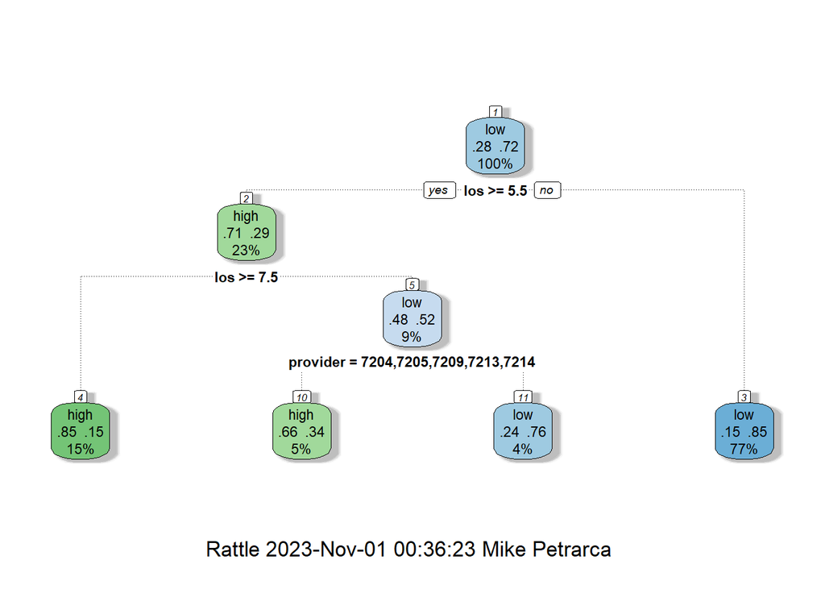

```r
# Plotting the decision tree with the 'fancyRpartPlot' function by Rattle.

fancyRpartPlot(tree)
```

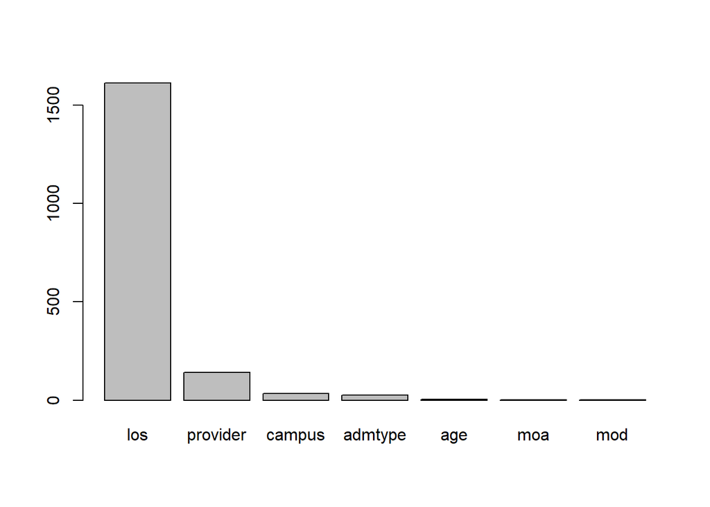

```r
# Plotting the variable importance of the tree using a bar plot. The variables with the greatest importance are `los`, `provider`, and `campus`.

barplot(tree$variable.importance)
```

3. Using caret for this question. Set `Training Control` to be: Use Cross-Validation of 5 folds across all models. Train & tune at least 2 different models (i.e. two different values for `method=` in the train function of caret). Plot the hyper-parameter tuning plots for each model.

```r
# Creating the first model with a training control parameter set. Here, the cross-validation of 5 folds was established using the argument 'number = 5'. This model uses the method 'ranger' with the tuning parameters 'mtry', 'splitrule', and 'min.node.size'. These parameters determine the number of varable candidates for each split, along with the splitting rule and the minimum node size for each tree. The model will then find the best combination of tuning parameters to corresponding to the highest training accuracy. The model is then evaluated against the testing data partition and a confusion matrix is created.

set.seed(64)

ctrl = trainControl(method = "cv",
                         number = 5)

tuneGrid = expand.grid(mtry = 2:4,
                       splitrule = c('gini', 'extratrees'),
                       min.node.size = c(1:10))

model1 <- train(target~., data=trainDf,
              method = "ranger",
              trControl = ctrl,
              tuneGrid = tuneGrid)

pred <- predict(model1, testDf)

cm1 <- confusionMatrix(data = pred, reference = testDf$target, positive = "high")

model1
```

```
## Random Forest
##
## 12753 samples
##     9 predictor
##     2 classes: 'high', 'low'
##
## No pre-processing
## Resampling: Cross-Validated (5 fold)
## Summary of sample sizes: 10203, 10203, 10203, 10202, 10201
## Resampling results across tuning parameters:
##
##   mtry  splitrule   min.node.size  Accuracy   Kappa
##   2     gini         1             0.7204579  0.0183903399
##   2     gini         2             0.7202227  0.0176808528
##   2     gini         3             0.7207716  0.0199594784
```

[output cut: 61 more lines]

```r
# Displaying the confusion matrix and statistics. The first model had a testing accuracy of 0.8481. The testing accuracy is not too different from the training accuracy of 0.8465463 suggesting that the model is not over fit. This model is a random forest with the parameter 'mtry = 4', the split rule set to 'gini', and a minimum node size of 10.

cm1
```

```
## Confusion Matrix and Statistics
##
##           Reference
## Prediction  high   low
##       high 17753  2691
##       low  14744 79586
##
##                Accuracy : 0.8481
##                  95% CI : (0.846, 0.8502)
##     No Information Rate : 0.7169
##     P-Value [Acc > NIR] : < 2.2e-16
##
##                   Kappa : 0.5785
##
##  Mcnemar's Test P-Value : < 2.2e-16
##
##             Sensitivity : 0.5463
##             Specificity : 0.9673
##          Pos Pred Value : 0.8684
##          Neg Pred Value : 0.8437
##              Prevalence : 0.2831
##          Detection Rate : 0.1547
##    Detection Prevalence : 0.1781
##       Balanced Accuracy : 0.7568
##
##        'Positive' Class : high
##
```

```r
# Creating the second model with a training control parameter set. Here, the cross-validation of 5 folds was established. This model uses the method 'pls' (Partial Least Squares). With this method, the tuning parameter 'ncomp' is set to the interval from 2 to 5 to determine the correct number of factors. This method essentially uses factor analysis to combine variables into factors to predict the target.

set.seed(64)

ctrl = trainControl(method = "cv",
                         number = 5)

tuneGrid = expand.grid(ncomp = 2:5)

model2 <- train(target~., data=trainDf,
              method = "pls",
              trControl = ctrl,
              tuneGrid = tuneGrid)

pred <- predict(model2, testDf)

cm2 <- confusionMatrix(data = pred, reference = testDf$target, positive = "high")

model2
```

```
## Partial Least Squares
##
## 12753 samples
##     9 predictor
##     2 classes: 'high', 'low'
##
## No pre-processing
## Resampling: Cross-Validated (5 fold)
## Summary of sample sizes: 10203, 10203, 10203, 10202, 10201
## Resampling results across tuning parameters:
##
##   ncomp  Accuracy   Kappa
##   2      0.7573125  0.1955621
##   3      0.7784843  0.3181954
##   4      0.7792678  0.3123320
##   5      0.7807573  0.3249643
##
## Accuracy was used to select the optimal model using the largest value.
## The final value used for the model was ncomp = 5.
```

```r
# Displaying the confusion matrix and statistics for the second model.

cm2
```

```
## Confusion Matrix and Statistics
##
##           Reference
## Prediction  high   low
##       high  9406  1738
##       low  23091 80539
##
##                Accuracy : 0.7837
##                  95% CI : (0.7813, 0.786)
##     No Information Rate : 0.7169
##     P-Value [Acc > NIR] : < 2.2e-16
##
##                   Kappa : 0.3349
##
##  Mcnemar's Test P-Value : < 2.2e-16
##
##             Sensitivity : 0.28944
##             Specificity : 0.97888
##          Pos Pred Value : 0.84404
##          Neg Pred Value : 0.77718
##              Prevalence : 0.28314
##          Detection Rate : 0.08195
##    Detection Prevalence : 0.09710
##       Balanced Accuracy : 0.63416
##
##        'Positive' Class : high
##
```

Plot the hyper-parameter tuning plots for each model.

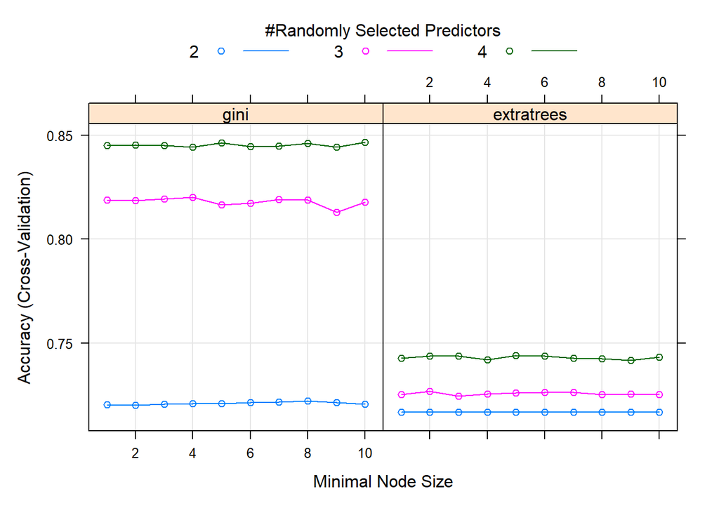

```r
# Plotting the hyper-parameter tuning plots for each model.

plot(model1)
```

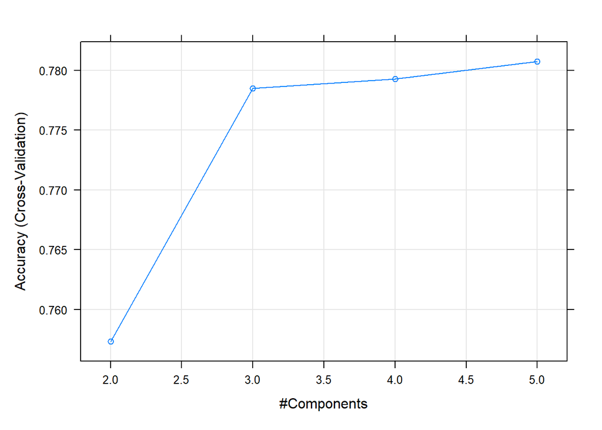

```r
plot(model2)
```

4. Plot the comparison of the models in 3.

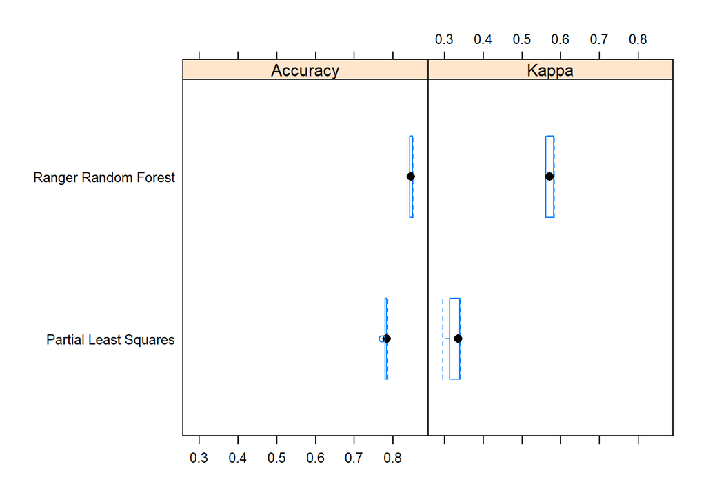

```r
# Plotting the comparison of the models from question 3.

comparison <- resamples(list('Ranger Random Forest' = model1,
'Partial Least Squares' = model2))

bwplot(comparison)
```

5. What is your final selection for the model? Test the accuracy of your final model on the test data.

```r
# After comparing the two models, the best model is clearly the first model. This model displayed both the best training and testing accuracy. Despite both models having very high specificity the second model had a far lower sensitivity. Therefore, the first model using the 'ranger' method is the best model at predicting the level of total charge. This model had a testing accuracy of 0.8481.

cm1
```

```
## Confusion Matrix and Statistics
##
##           Reference
## Prediction  high   low
##       high 17753  2691
##       low  14744 79586
##
##                Accuracy : 0.8481
##                  95% CI : (0.846, 0.8502)
##     No Information Rate : 0.7169
##     P-Value [Acc > NIR] : < 2.2e-16
##
##                   Kappa : 0.5785
##
##  Mcnemar's Test P-Value : < 2.2e-16
##
##             Sensitivity : 0.5463
##             Specificity : 0.9673
##          Pos Pred Value : 0.8684
##          Neg Pred Value : 0.8437
##              Prevalence : 0.2831
##          Detection Rate : 0.1547
##    Detection Prevalence : 0.1781
##       Balanced Accuracy : 0.7568
##
##        'Positive' Class : high
##
```

6. Create another `target` variable (binary), decide the input variables and redo 1 to 5.

6.1. Use `filter` function to filter out rows where `raceethn==''` or `admtype==''`. Make sure all the categorical variables are factor, numeric variables are numeric. Set Training : Testing Split = 10 : 90

```r
# Resetting the dataframe back to checkpoint by reassigning the dataframe with read_csv. Therefore, the empty categories and variable classes will need to be changed once more. The columns containing missing values will need to be dropped and the data will also need to be partitioned again.

library(tidyverse)
library(lattice)
df <- read_csv('midterm.csv')
# Removing empty categories within columns.

df <- df %>% filter(raceethn != '' & admtype != '') %>%
  select(-c("payfix","preopday","obs_hour","nicu_day"))

# Creating the target variable.

timeAdmitted <- ifelse(df$los < mean(df$los), 'short.term','long.term')

df$target <- timeAdmitted

# Input Variables: `moa`, `age`, `sex`, `asource`, `tot`, `icu`, `ccu`, `payer`, `service`, `provider.`

df <- df %>%
  select('moa','age','sex','asource','tot','icu','ccu','payer','service','provider','target')

head(df)
```

```
## # A tibble: 6 × 11
##     moa   age   sex asource    tot icu    ccu    payer service provider target
##   <dbl> <dbl> <dbl> <chr>    <dbl> <chr>  <chr>  <chr> <chr>      <dbl> <chr>
## 1     1     0     1 S         3653 000000 000000 6     00          7214 short.t…
## 2     1    76     2 1        44075 000000 000000 0     00          7214 short.t…
## 3    12    50     2 1        99235 000000 000000 5     00          7214 short.t…
## 4     1     0     1 S         5412 000000 000000 G     00          7214 short.t…
## 5    12     0     1 S        93547 000000 000000 7     00          7214 long.te…
## 6    12     0     2 T       207366 000000 000000 G     00          7214 long.te…
```

```r
# Checking for missing values in the dataframe.

df %>% is.na %>% colSums
```

```
##      moa      age      sex  asource      tot      icu      ccu    payer
##        0        0        0        3        0        0        0        0
##  service provider   target
##        0        0        0
```

```r
# Removing the three rows containing missing values and displaying results.

df <- drop_na(df)

df %>% is.na %>% colSums
```

```
##      moa      age      sex  asource      tot      icu      ccu    payer
##        0        0        0        0        0        0        0        0
##  service provider   target
##        0        0        0
```

```r
# Updating classes. The classes of the variables `age` and `tot` are already numeric so they were not changed.

set.seed(2023)

df <- df %>%

  mutate(target = as.factor(target),

         icu = as.numeric(icu),

         ccu = as.numeric(ccu),

         payer = as.factor(payer),

         service = as.factor(service),

         moa = as.factor(moa),

         provider = as.factor(provider),

         asource = as.factor(asource),

         sex = as.factor(sex)

         )

# Creating partition for 10% training data and 90% testing data.

partition <- createDataPartition(df$target, p = .10,

                                  list = FALSE)

trainDf <- df[ partition,]

testDf <- df[-partition,]

head(df)
```

```
## # A tibble: 6 × 11
##   moa     age sex   asource    tot   icu   ccu payer service provider target
##   <fct> <dbl> <fct> <fct>    <dbl> <dbl> <dbl> <fct> <fct>   <fct>    <fct>
## 1 1         0 1     S         3653     0     0 6     00      7214     short.term
## 2 1        76 2     1        44075     0     0 0     00      7214     short.term
## 3 12       50 2     1        99235     0     0 5     00      7214     short.term
## 4 1         0 1     S         5412     0     0 G     00      7214     short.term
## 5 12        0 1     S        93547     0     0 7     00      7214     long.term
## 6 12        0 2     T       207366     0     0 G     00      7214     long.term
```

6.2. Train a decision tree using `rpart`. Plot the decision tree. Plot the variable importance ranked by the tree.

```r
# Creating a decision tree model. The tree was trained on the training data with a max depth of 3 using rpart's control parameter. For additional statistics on the tree, a confusion matrix was created and the accuracy was created. The testing accuracy of this model is approximately 0.8098823.

set.seed(64)

tree <- rpart(target ~ ., data = trainDf,

              control = rpart.control(maxdepth = 3))

# Creating predictions on the testing data.

prediction <- predict(tree, testDf, type = "class")

# Creating a confusion matrix to test the predictions.

cm <- confusionMatrix(data = prediction,

                      reference = testDf$target, positive = "long.term")

cm$overall[1]
```

```
##  Accuracy
## 0.8098823
```

[figure not shown]

```r
# Plotting the decision tree with Rattle's 'fancyRpartPlot()' function.

fancyRpartPlot(tree)
```